# Taylors_Law_Final_Knit

Soren Maret 2025-04-24

Chapter_01

##GOAL##: Do a proof of concept that their is a scaling (power law) relationship in the gene expression pattern of dox exposed RNA-seq data.

Specifically I will investigate if Taylors Law, an imperical law from ecology, which explains the scaling relationship between the mean and standard deviation presents in our data.

Taylors law is expressed in the following way:

sd = b * mean^a

This related the standard deviation (stdev) to the mean by 2 constants b and a where a is our scaling value and b is a normaling constant

We can rearrange this to using logarithms to get these values by themselves. to do this, since our bases are not equal, we will use the natural logarithm (ln):

ln(sd) = a * ln(mean) + ln(b)

Notice how this is the equation of a line. we can derive the values for a (slope) and b (y-intercept), which are the biologically informative ones, by running a linear regression with high enough statistical signifigance (measured by the regression constant R)

for further reading see the resources below: https://necsi.edu/power-law https://www.nature.com/articles/s41562-016-0012 https://journals.aps.org/prx/abstract/10.1103/PhysRevX.12.011051#:~:text=Popular%20Summary,varies%20from%20cell%20to%20cell.

In our case we will examine the mean expression of a gene compaired to its standard deviation. to do this we will use our counts matrix produced from our nextflow run.

Lets load in some data shall we? To do a proof of concept I will run both human and mouse data in parallel.

```r
Human_counts <- read_tsv("/scratch/Shares/rinnclass/MASTER_CLASS/STUDENTS/genehomies/DATA/HUMAN/salmon.merged.gene_counts.tsv")
Mouse_counts <- read_tsv("/scratch/Shares/rinnclass/MASTER_CLASS/STUDENTS/genehomies/DATA/MOUSE/salmon.merged.gene_counts.tsv")
#cool! now lets remove the logical values to our results dataframe which we ill call taylor_values_human or taylor_values_mouse

#lets do this for humans:
#making a dataframe that contains our "gene_id" collumn:
taylor_values_human <- Human_counts["gene_id"]
#now lets move gene_names over as well
taylor_values_human <- cbind(taylor_values_human, Human_counts[c("gene_name")])
#looks just like our g2s.df from earlier this semester!

#now for the mice:
taylor_values_mouse <- Mouse_counts["gene_id"]
#now lets move gene_names over as well
taylor_values_mouse <- cbind(taylor_values_mouse, Mouse_counts[c("gene_name")])
#great! this all worked out nicely!
```

Now we have our new dataframes which we can load all of our means and standard deviations into so we can later run analysis. in order to successfully do these calculations we need to remove the charaters and make our dataframes numeric.We can do this in any order.

```r
#first, lets remove the collumns gene_name and gene_id as they are characters and will just become N/As
#removes gene_id
Human_counts <- Human_counts[, !(names(Human_counts)) %in% "gene_id"]
#removes gene_name
Human_counts <- Human_counts[, !(names(Human_counts)) %in% "gene_name"]
#makes out counts matrix numeric
Human_counts <- data.frame(lapply(Human_counts, as.numeric))

#we will do the same for our mouse data:
Mouse_counts <- Mouse_counts[, !(names(Mouse_counts)) %in% "gene_id"]
#removes gene_name
Mouse_counts <- Mouse_counts[, !(names(Mouse_counts)) %in% "gene_name"]
#makes out counts matrix numeric
Mouse_counts <- data.frame(lapply(Mouse_counts, as.numeric))
```

Great! all is well with the cosmos. Now Taylors Law looks at 2 things an independent variable: the mean of a gene (in our case, often its a taxa) and an indepdent variable: the standard deviation of that gene. so we need to calculate these values as values in our enviornment.

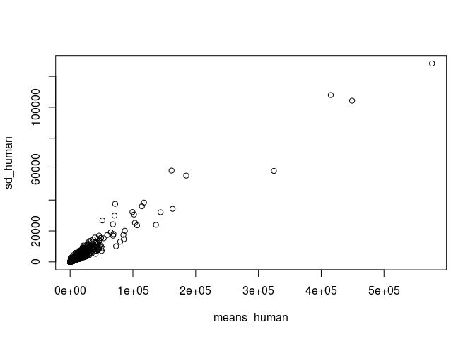

```r
#here is the anaylsis for the human counts:
means_human <- rowMeans(Human_counts)
#now for the standard deviation accross the rows:
sd_human <- apply(Human_counts, 1, sd)

#now we can do the same for our mouse data
means_mouse <- rowMeans(Mouse_counts)
#now for the standard deviation accross the rows:
sd_mouse <- apply(Mouse_counts, 1, sd)

#Sweet!! now lets plot this just to see whats up?
plot(means_human, sd_human)
```

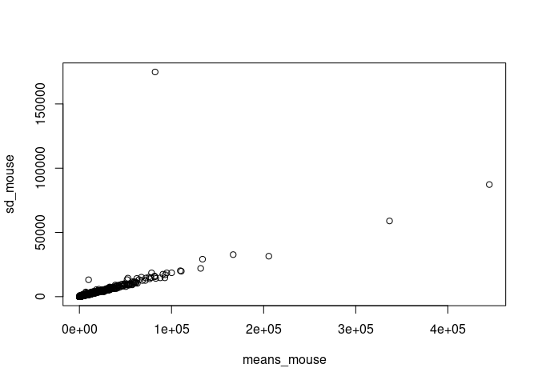

```r
plot(means_mouse, sd_mouse)
```

```r
#cool! our data is linear but the values varie massively! but on the bright side this is a proof of concept!!!
```

Now lets move onto making this all analyzable in chapter 02: but first, some housekeeping:

```r
taylor_values_human <- cbind(taylor_values_human, mean = means_human, sd = sd_human)

taylor_values_mouse <- cbind(taylor_values_mouse, mean = means_mouse, sd = sd_mouse)

save(Human_counts, Mouse_counts, taylor_values_human, taylor_values_mouse, means_human, means_mouse, sd_human, sd_mouse, file = "/scratch/Shares/rinnclass/MASTER_CLASS/STUDENTS/genehomies/RESULTS/TPL_ANALYSIS/RData/Chapter_01.RData")
#cleaning
rm(list = ls())
```

Chapter_02

##GOAL##: Do all realivent transformations to our data such as log transformations and sort out all genes that didn’t change or returned a 0.0000 for their mean.

```r
load("/scratch/Shares/rinnclass/MASTER_CLASS/STUDENTS/genehomies/RESULTS/TPL_ANALYSIS/RData/Chapter_01.RData")
##our envionrment should be identical to where we left of in chapter_01
```

Great! recall how in our plots that we generated in chapter 01 were super dense close to zero and thinned out as we went away from the x-axis? This indicates that few genes are very highly expressed. precisely, if there were 10 genes in our data, then 50% of our expression would be from one gene.

To get around this we need to log transform our data using the natural logarithm to get our slope and intercept values described in chapter 01.

```r
#we will create value lists that we will merge into our taylor_values dataframes later
#in R the log function is the natural log, how lovely!
#heres the log_mean:
log_m_human <- log(means_human)
#heres the log_sd:
log_sd_human <- log(sd_human)

#Now we can just repeate this for mice
#heres the log_mean:
log_m_mouse <- log(means_mouse)
#heres the log_sd:
log_sd_mouse <- log(sd_mouse)
```

Great, we could do the gut check plotting we did earlier or we could just read eveything into our taylot_values dataframes just to make life easy

```r
#for humans
taylor_values_human <- taylor_values_human %>%
  mutate(log_m = log_m_human)
taylor_values_human <- taylor_values_human %>%
  mutate(log_sd = log_sd_human)
#for mice
taylor_values_mouse <- taylor_values_mouse %>%
  mutate(log_m = log_m_mouse)
taylor_values_mouse <- taylor_values_mouse %>%
  mutate(log_sd = log_sd_mouse)
```

Note how some rows have returned a inf or -inf value for their results. This is fine as ggplot just ignore these, but we should remove it. To do this we will just remove all rows in our mean or standard deviation collums that are zero. While we are at it lets rename our dataframes after the sorting.

```r
#humans first!
taylor_values_human_02 <- taylor_values_human[taylor_values_human$mean != 0, ]
taylor_values_human_02 <- taylor_values_human[taylor_values_human$sd != 0, ]
#now mice!
taylor_values_mouse_02 <- taylor_values_mouse[taylor_values_mouse$mean != 0, ]
taylor_values_mouse_02 <- taylor_values_mouse[taylor_values_mouse$sd != 0, ]
```

That got rid of a bunch of our data. now we can run our regressions. For this we will use ggplot2 in chapter_03!

```r
save(taylor_values_human_02, taylor_values_mouse_02, file = "/scratch/Shares/rinnclass/MASTER_CLASS/STUDENTS/genehomies/RESULTS/TPL_ANALYSIS/RData/Chapter_02.RData")

rm(list = ls())
```

Chapter_03

##GOAL##: We Will now run regressions on our log transformed data to get our parameters “a” and “b”. This will be our main result, but then I will do additional analysis that i will expand upon for our final project!

```r
load("/scratch/Shares/rinnclass/MASTER_CLASS/STUDENTS/genehomies/RESULTS/TPL_ANALYSIS/RData/Chapter_02.RData")
```

Cool lets get down to it. I will slowly build up our analysis using ggplot2 to do our analysis. recall from chapter one that there are 2 equivilent forms of taylors law:

01: exponential: sd = b * mean^a 02: linear: ln(sd) = a * ln(mean) + ln(b)

In chapter_01 we saw that our data was linear, but some genes were expressed at a very high level (that 1:10 ratio discussed in chapter_02). In Chapter_02 we applied logs to our mean values and sd values and put them into our taylor values dataframes. we then sorted out any that were Zero. this will decrease the error at the fringes of our data.

I will run this analysis on our mouse data first to build up. to begin I will simply plot our log transformed values against one another.

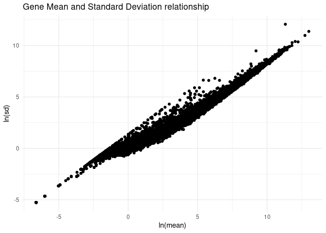

```r
ggplot(taylor_values_mouse_02, aes(x = log_m, y = log_sd)) +
  geom_point() +
  labs(title = "Gene Mean and Standard Deviation relationship", x = "ln(mean)", y = "ln(sd)") +
  theme_minimal()
```

Now lets add a regression line and see if we can perform a regression

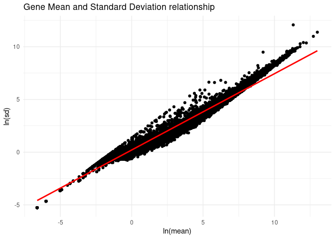

```r
ggplot(taylor_values_mouse_02, aes(x = log_m, y = log_sd)) +
  geom_point() +
  geom_smooth(method = "glm", color = "red", se = TRUE) +  # Regression line
  labs(title = "Gene Mean and Standard Deviation relationship", x = "ln(mean)", y = "ln(sd)") +
 theme_minimal()
```

Is our line statistically signifigant? in order to test this we can ask ggplot to calculate an regression coefficient R which will be between 0.0 and 1.0 with 0 being no relationship and 1 being perfectly related.

Becuase I dont want to install ggpubr I will go about calculating this the hard way:

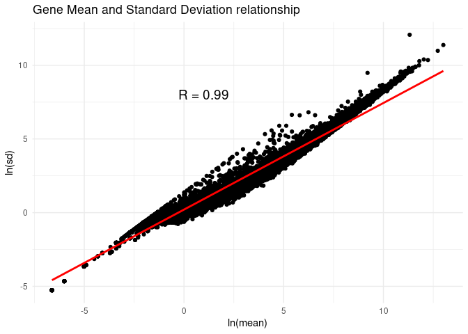

```r
#Calculating the coorelations coefficient:
cor_value <- cor(taylor_values_mouse_02$log_m, taylor_values_mouse_02$log_sd, use = "complete.obs")
#adding it to our plot:
ggplot(taylor_values_mouse_02, aes(x = log_m, y = log_sd)) +
  geom_point() +
  geom_smooth(method = "glm", color = "red", se = TRUE) +  # Regression line
  annotate("text", x = 1, y = 8, label = paste("R =", round(cor_value, 2)), size = 5) + #R^2 value display
  labs(title = "Gene Mean and Standard Deviation relationship", x = "ln(mean)", y = "ln(sd)") +
 theme_minimal()
```

##RESULT##: Our data are almost perfectly related meaning that a change in mean is almsot completely reflected as a change in sd

The cutoff for signifigance with R^2 is usually around 0.9 meaning that our data are signifigant.

Now that we have established that we can move onto extracting the “a” and “b” values by asking ggplot2 to add an equation for our line. But becuase I am lazy and dont want to install ggpubr i will have base R calculate the equation of my line.

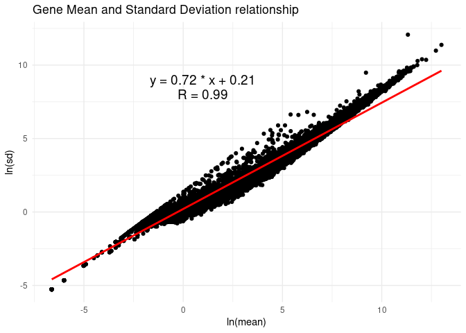

```r
lm_fit <- lm(log_sd ~ log_m, data = taylor_values_mouse_02)
eq <- paste("y =", round(coef(lm_fit)[2], 2), "* x +", round(coef(lm_fit)[1], 2))

# Compute Pearson correlation
cor_value <- cor(taylor_values_mouse_02$log_m, taylor_values_mouse_02$log_sd, use = "complete.obs")

# Plot
ggplot(taylor_values_mouse_02, aes(x = log_m, y = log_sd)) +
  geom_point() +
  geom_smooth(method = "glm", color = "red", se = TRUE) +
  annotate("text", x = 1, y = 8, label = paste("R =", round(cor_value, 2)), size = 5) +
  annotate("text", x = 1, y = 9, label = eq, size = 5) + # Regression equation
  labs(title = "Gene Mean and Standard Deviation relationship", x = "ln(mean)", y = "ln(sd)") +
  theme_minimal()
```

##RESULT##: We now have our values for “a” and “b”. a = 0.72 b = e^0.21 = 1.23. Where e is eulers exponential constant and 0.21 is the log value of b.

Now lets make it look nice:

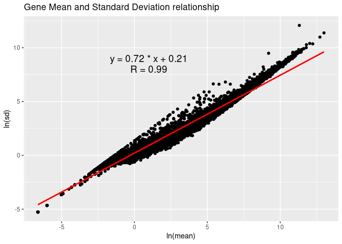

```r
ggplot(taylor_values_mouse_02, aes(x = log_m, y = log_sd)) +
  geom_point() +
  geom_smooth(method = "glm", color = "red", se = TRUE) +  # Regression line
 annotate("text", x = 1, y = 8, label = paste("R =", round(cor_value, 2)), size = 5) +
  annotate("text", x = 1, y = 9, label = eq, size = 5) + # Regression equation
  labs(title = "Gene Mean and Standard Deviation relationship", x = "ln(mean)", y = "ln(sd)") +
 theme_set(theme_minimal() +
   theme(
              text = element_text(size = 14, family = "Georgia"),
              plot.title = element_text(face = "bold", hjust = 0.5),
              axis.text = element_text(color = "black"),
              panel.grid.major = element_line(color = "gray80"),
              panel.grid.minor = element_blank()
            ))
```

Awesome! Now lets just use this final equation to plot our human data and extract those values:

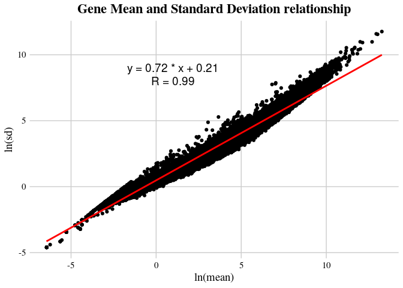

```r
#calculate the line:
lm_fit_human <- lm(log_sd ~ log_m, data = taylor_values_human_02)
eq_human <- paste("y =", round(coef(lm_fit_human)[2], 2), "* x +", round(coef(lm_fit)[1], 2))

# Compute Pearson correlation
cor_value_human <- cor(taylor_values_human_02$log_m, taylor_values_human_02$log_sd, use = "complete.obs")

ggplot(taylor_values_human_02, aes(x = log_m, y = log_sd)) +
  geom_point() +
  geom_smooth(method = "glm", color = "red", se = TRUE) +  # Regression line
 annotate("text", x = 1, y = 8, label = paste("R =", round(cor_value_human, 2)), size = 5) +
  annotate("text", x = 1, y = 9, label = eq_human, size = 5) + # Regression equation
  labs(title = "Gene Mean and Standard Deviation relationship", x = "ln(mean)", y = "ln(sd)") +
 theme_set(theme_minimal() +
   theme(
              text = element_text(size = 14, family = "Georgia"),
              plot.title = element_text(face = "bold", hjust = 0.5),
              axis.text = element_text(color = "black"),
              panel.grid.major = element_line(color = "gray80"),
              panel.grid.minor = element_blank()
            ))
```

```r
#lets just save all new files here:
save(taylor_values_human_02, taylor_values_mouse_02, lm_fit, lm_fit_human, cor_value, cor_value_human, eq, eq_human, file = "/scratch/Shares/rinnclass/MASTER_CLASS/STUDENTS/genehomies/RESULTS/TPL_ANALYSIS/RData/Chapter_03.RData")

rm(list = ls())
```

##FUTURE_DIRECTIONS## 1. Now that we know that these distrbutions are similar, I want to look at which genes are being highly expressed and examine if they are paralogues to one another. 2. I want to do timecourse analysis on these data and determine the change in the coefficients over time. 3. Investigate isomorphic distributions in other feilds with these values.

Chapter_04.1

```r
#loading in data
Mouse_counts <- read_tsv("/scratch/Shares/rinnclass/MASTER_CLASS/STUDENTS/genehomies/DATA/MOUSE/salmon.merged.gene_counts.tsv")
#using grep to seperate all timecourse values into seperate dataframes based on time point
counts_0 <- Mouse_counts[, grep("^WT_0_", colnames(Mouse_counts))]
counts_12 <- Mouse_counts[, grep("^WT_12_", colnames(Mouse_counts))]
counts_24 <- Mouse_counts[, grep("^WT_24_", colnames(Mouse_counts))]
counts_48 <- Mouse_counts[, grep("^WT_48_", colnames(Mouse_counts))]
counts_96 <- Mouse_counts[, grep("^WT_96_", colnames(Mouse_counts))]
```

```r
# making a g2s fir downstream analysis and filtering
g2s <- Mouse_counts[, c(1,2)]
#making mouse counts numeric
Mouse_counts <- Mouse_counts[, -c(1,2)]
```

```r
#lets write a function that can do all of our calculations for us to save few days worth of time.
taylor_func <- function(df) {
  #check if dataframe is numeric
  df_numeric <- df[sapply(df, is.numeric)]
  #do mean and standard deviation
  row_mean <- rowMeans(df_numeric, na.rm = TRUE)
  row_sd <- apply(df_numeric, 1, sd, na.rm = TRUE)
  #take logs of these values for actual analysis
  ln_mean <- log(row_mean)
  ln_sd <- log(row_sd)

  # Combine results into dataframe
  result_df <- data.frame(
    row_mean = row_mean,
    row_sd = row_sd,
    log_m = ln_mean,
    log_sd = ln_sd
  )

  # Remove rows where row_mean is 0
  result_df <- result_df[result_df$row_mean !=0, ]
  #return our results to the global enviornment.
  return(result_df)
}
```

```r
# this efficiency stuff is actually so fun, here is a nested for loop that will retrieve all of the parameters for taylors law and run some statistics for us

# I want to do this globally for all dataframes in my enviornment. lets get them
df_names <- ls()[sapply(ls(), function(x) is.data.frame(get(x)))]

#lets initilaize a tibble.
regression_results <- tibble(
  Dataset = character(),
  Slope = numeric(),                # regression slope (a in y = ax + b)
  Intercept = numeric(),            # regression intercept (b in y = ax + b)
  R_squared = numeric(),            # R² value
  P_value = numeric(),              # p-value from the regression slope
  T_value_vs_first = numeric(),     # t-stat comparing slope to that of first model
  P_value_vs_first = numeric(),     # p-value of the t-test comparing slopes
  time = numeric()
)


# Initialize variables to store the first model's parameters (for p_val)
first_model <- NULL  # used to store the first model object
b1 <- NULL           # slope from the first model
se1 <- NULL          # standard error of slope from first model
df1 <- NULL          # degrees of freedom of first model

# Loop through each dataframe name in df_names
for (i in seq_along(df_names)) {
  df_name <- df_names[i]          # current dataframe name as string
  df <- get(df_name)              # retrieve dataframe object from the environment
  df <- taylor_func(df)           # apply your preprocessing/statistics function

  # Check if the expected columns exist before running regression
  if (all(c("log_m", "log_sd") %in% colnames(df))) {
    # Filter out incomplete or infinite values
    valid <- complete.cases(df$log_m, df$log_sd) &
             !is.infinite(df$log_m) &
             !is.infinite(df$log_sd)

    # Continue only if enough valid data points exist
    if (sum(valid) >= 2) {
      # Perform linear regression: log_sd ~ log_m
      model <- lm(log_sd ~ log_m, data = df[valid, ])

      # Extract regression slope (a), intercept (b), R², and p-value
      a <- coef(model)[["log_m"]]
      b <- coef(model)[["(Intercept)"]]
      r2 <- summary(model)$r.squared
      p_val <- coef(summary(model))["log_m", "Pr(>|t|)"]

      # If this is the first model, store its values for later comparison
      if (is.null(first_model)) {
        first_model <- model
        b1 <- a
        se1 <- coef(summary(model))["log_m", "Std. Error"]
        df1 <- df.residual(model)

        # No comparison yet for first model
        t_val <- NA
        p_val_vs_first <- NA
      } else {
        # For subsequent models, extract slope and SE
        b2 <- a
        se2 <- coef(summary(model))["log_m", "Std. Error"]
        df2 <- df.residual(model)

        # Calculate t-statistic to compare slope with first model's slope
        t_val <- (b1 - b2) / sqrt(se1^2 + se2^2)
        df_comp <- min(df1, df2)  # conservative degrees of freedom
        p_val_vs_first <- 2 * pt(-abs(t_val), df = df_comp)  # two-tailed p-value
      }

      # Add results to the output tibble
      regression_results <- add_row(
        regression_results,
        Dataset = df_name,
        Slope = a,
        Intercept = b,
        R_squared = r2,
        P_value = p_val,
        T_value_vs_first = t_val,
        P_value_vs_first = p_val_vs_first,
        time = i
      )
    } else {
      # Warn if there aren't enough points to perform regression
      warning(paste("Skipping", df_name, "- not enough valid points."))
    }

  } else {
    # Warn if expected columns are missing
    warning(paste("Skipping", df_name, "- missing log_m or log_sd columns."))
  }
}

# Print out the full regression summary table
regression_results <- regression_results %>% filter(row_number() <= n()-1)

print(regression_results)
```

```
## # A tibble: 5 × 8
##   Dataset   Slope Intercept R_squared P_value T_value_vs_first P_value_vs_first
##   <chr>     <dbl>     <dbl>     <dbl>   <dbl>            <dbl>            <dbl>
## 1 counts_0  0.717    -0.240     0.938       0            NA          NA
## 2 counts_12 0.812    -0.195     0.958       0           -63.3         0
## 3 counts_24 0.668    -0.172     0.921       0            29.9         4.19e-193
## 4 counts_48 0.710    -0.220     0.932       0             4.05        5.11e-  5
## 5 counts_96 0.785    -0.205     0.953       0           -44.6         0
## # ℹ 1 more variable: time <dbl>
```

##RESULTS## 1. Super significant results in our slope regression parameter here likely driven by a high number of genes. 2. A consistently high coorelation value tracks with our slope parameter value which is curious.

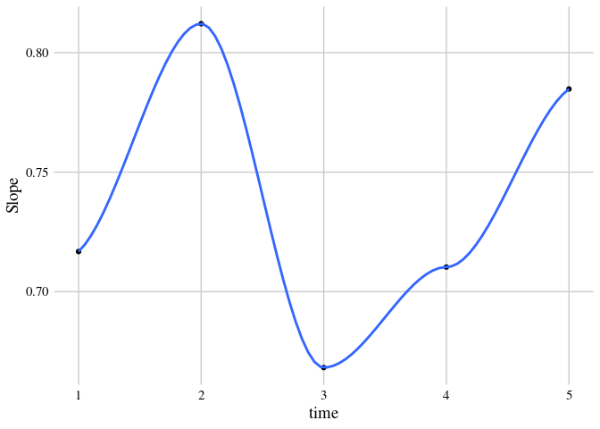

```r
#Lets take a look at our data graphically!
# slope over time
ggplot(regression_results, mapping = aes(x = time, y = Slope)) +
  geom_point() +
  geom_smooth(formula = 'y ~ x', method = "loess")
```

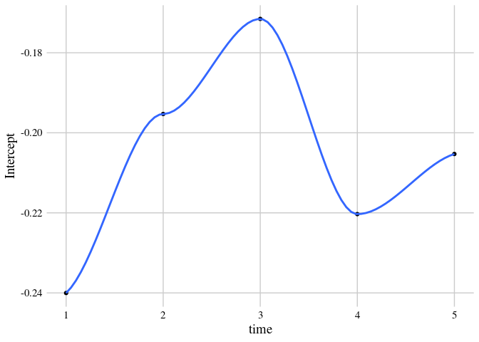

```r
# intercept over time
ggplot(regression_results, mapping = aes(x = time, y = Intercept)) +
  geom_point() +
  geom_smooth(formula = 'y ~ x', method = "loess")
```

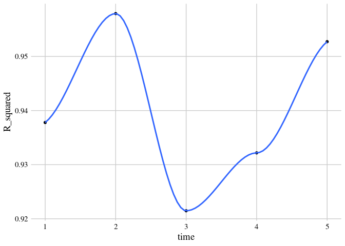

```r
# R^2 over time
ggplot(regression_results, mapping = aes(x = time, y = R_squared)) +
  geom_point() +
  geom_smooth(formula = 'y ~ x', method = "loess")
```

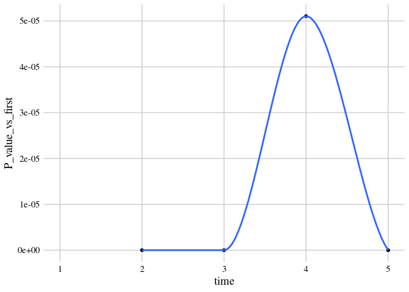

```r
# P val over time
ggplot(regression_results, mapping = aes(x = time, y = P_value_vs_first)) +
  geom_point() +
  geom_smooth(formula = 'y ~ x', method = "loess")
```